# StockResearch

Gabriel Foix

2020-09-22

Find the best stock to buy

### Factor 1: Quality

1. Healthy debts: A company shoud generate cash in order to repay its debt. The **Free Cash Flow to Debt** ratio is a good indicator of how quick a company pays back its debt. The lower this ratio the better.

FCF2D = $\frac{Debt}{Free Cash Flow}$

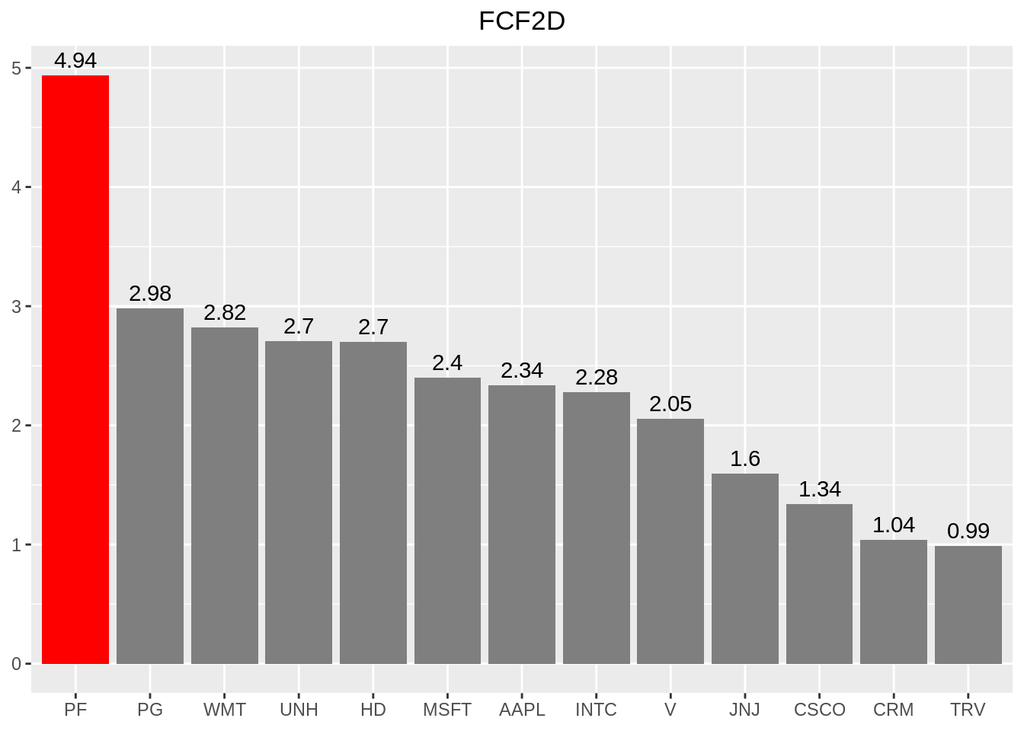

2. Profitability: ROA

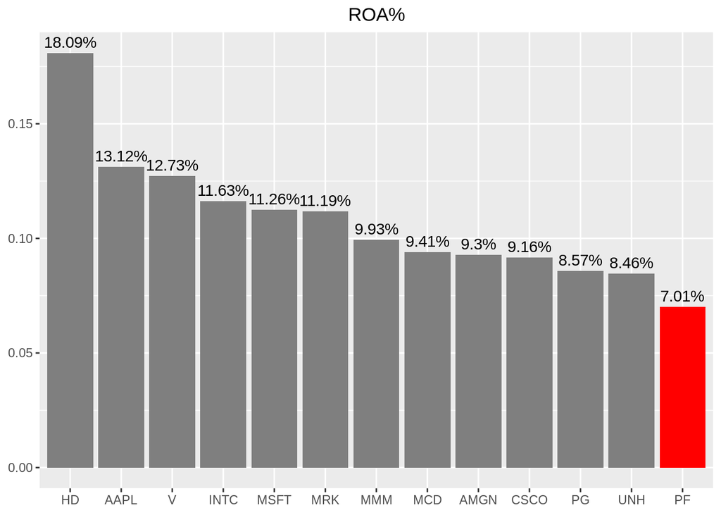

3. High Margin: We look for companies that generate free cash flow compare to its price. The **Free Cash Flow to Entreprise Value** ratio tells us how many years of cash flow would be needed to the return the 100% of the investment. Again, the lower, the better. Values bellow 1 would mean "free lunch".

FCF2EV = $\frac{EV}{Free Cash Flow}$

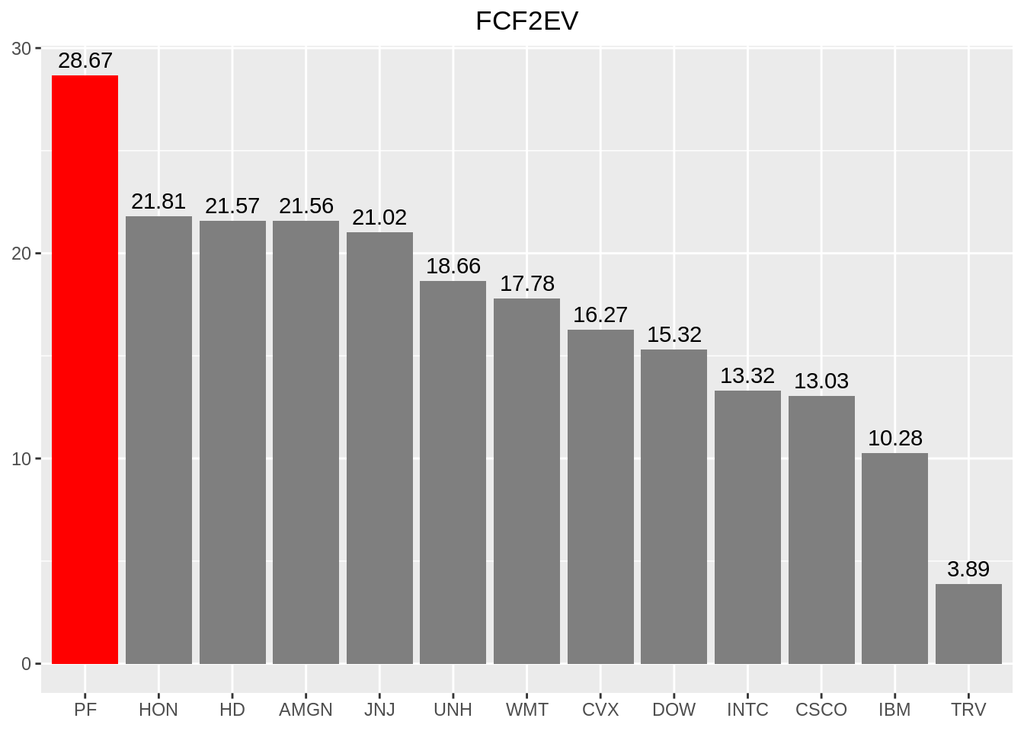

### Factor 2: Momentum

Don't hold onto a stock simply because it is high quality. So called quality stocks have cycles too. Stan Weinstein (page 177)

Generic Intermediate-Term Momentum Based on Gray-Vogel (page 80)

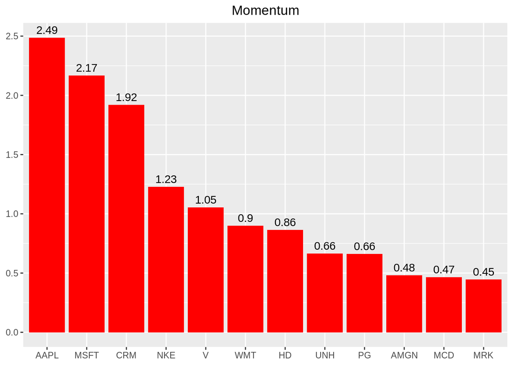

### Factor 3: Timing Signal

Sell Signal - Pr < 1% SMA 30 weeks and slope negative (< 0.1) Hold Signal - No Sell

### Summary

Summary

| Ticker | Signal | Quality | Momentum | Final_rank |
| --- | --- | --- | --- | --- |
| HD | HOLD | 27.0 | 24 | 29.5 |
| AAPL | HOLD | 21.0 | 30 | 29.5 |
| INTC | SELL | 30.0 | 18 | 28.0 |
| V | HOLD | 19.5 | 26 | 27.0 |
| CSCO | HOLD | 29.0 | 16 | 26.0 |
| MSFT | HOLD | 15.5 | 29 | 25.0 |
| UNH | HOLD | 19.5 | 23 | 24.0 |
| WMT | HOLD | 17.0 | 25 | 23.0 |
| AXP | HOLD | 28.0 | 10 | 22.0 |
| MRK | HOLD | 18.0 | 19 | 20.5 |
| JNJ | HOLD | 24.0 | 13 | 20.5 |
| CRM | HOLD | 8.0 | 28 | 19.0 |
| JPM | HOLD | 26.0 | 9 | 17.5 |
| AMGN | HOLD | 14.0 | 21 | 17.5 |
| PG | HOLD | 12.0 | 22 | 16.0 |
| NKE | HOLD | 4.0 | 27 | 15.0 |
| GS | HOLD | 25.0 | 5 | 14.0 |
| TRV | HOLD | 22.0 | 7 | 13.0 |
| MCD | HOLD | 6.0 | 20 | 12.0 |
| BA | SELL | 23.0 | 2 | 10.5 |
| HON | HOLD | 11.0 | 14 | 10.5 |
| VZ | HOLD | 7.0 | 15 | 9.0 |
| MMM | HOLD | 15.5 | 4 | 8.0 |
| IBM | HOLD | 13.0 | 6 | 7.0 |
| DOW | HOLD | 10.0 | 8 | 5.5 |
| DIS | HOLD | 1.0 | 17 | 5.5 |
| CAT | HOLD | 4.0 | 12 | 4.0 |
| KO | HOLD | 2.0 | 11 | 3.0 |
| CVX | SELL | 9.0 | 3 | 2.0 |
| WBA | SELL | 4.0 | 1 | 1.0 |